# ShowImagefromZEN slides

In order to make Python aware of ZEN Scripting DLLs one must register those in order to make them available for the COM interface. This is done be running the **regScripting_Release.bat** as adminsitrator. A detailed description on how to to this can be found inside the application note: **Control ZEN form Python**.

To run this notebook the follwing files are required:

- **regScripting.bat**

Additionally the package **bfimage** is required. It contains the following files:

- **bftools.py**
- **czitools.py**
- **misctools.py**
- **dispvalues.py**

This notebook demonstrates the capabilities of the .COM interface used to establish a connection between ZEN Blue and Python. This connection allows to use ZEN Blue OAD Simple-API within a python script.

Special thanks to Christoph Gohlke for providing the binaries on:

http://www.lfd.uci.edu/~gohlke/pythonlibs/

Requirements:

- PyWin32: http://www.lfd.uci.edu/~gohlke/pythonlibs/#pywin32
- Bioformats: http://www.lfd.uci.edu/~gohlke/pythonlibs/#bioformats
- Javabridge: http://www.lfd.uci.edu/~gohlke/pythonlibs/#javabridge
- vLFD: http://www.lfd.uci.edu/~gohlke/pythonlibs/#vlfd
- Numpy: https://pypi.python.org/pypi/numpy
- matplotlib: https://pypi.python.org/pypi/matplotlib/1.4.3

The first step is to do the required imports and setting up the correct path to the required extra tools.

```python
import sys
import win32com.client
import os
import matplotlib.pyplot as plt
import numpy as np
sys.path.append(r'c:\Users\M1SRH\Documents\Spyder_Projects\BioFormatsRead')
import bfimage as bf
%matplotlib inline

# Import the ZEN OAD Scripting into Python
Zen = win32com.client.GetActiveObject("Zeiss.Micro.Scripting.ZenWrapperLM")
# Get the active image from ZEN
CZIfilename = Zen.Application.Documents.ActiveDocument.FileName
imgbase = os.path.basename(CZIfilename)
imgdir = os.path.dirname(CZIfilename)
print 'Active Image: ', CZIfilename
```

```
Active Image:  C:\Users\M1SRH\Documents\Testdata_Zeiss\Zen_Black_Output\organoid uncleared smaller.czi
```

Here the CZI image is read into an 6D NumPy array. This example assumes XYCZT dimension order to be used during the acquisition. Of course this can be adapted to your needs.during the acquisition. The resulting NumPy array for XYCZT has the following shape:

**[series, time, zplane, channel, x, y]**

BioFormtas reads the CZI image **and** all important metainformation.

```python
# set path to bioformats_package
bf.set_bfpath(r'c:\Users\M1SRH\Documents\Software\BioFormats_Package\5.1.2\bioformats_package.jar')

# get image meta-information
MetaInfo = bf.bftools.get_relevant_metainfo_wrapper(CZIfilename)
img6d = bf.bftools.get_image6d(CZIfilename, MetaInfo['Sizes'])
```

```
Using bioformats_package : c:\Users\M1SRH\Documents\Software\BioFormats_Package\5.1.2\bioformats_package.jar
T:  1 Z:  423 C:  2 X:  512 Y:  512
Using czifile.py to get CZI Shape info.
Using BioFormats to get MetaInfo.
Using bioformats_package : c:\Users\M1SRH\Documents\Software\BioFormats_Package\5.1.2\bioformats_package.jar
```

```python
## show relevant image Meta-Information
print '\n'
print 'Image Directory      : ', imgdir
print 'Image Filename       : ', imgbase
print 'Images Dim Sizes     : ', MetaInfo['Sizes']
print 'Dimension Order*     : ', MetaInfo['DimOrder BF']
print 'Dimension Order CZI  : ', MetaInfo['OrderCZI']
print 'Total Series Number  : ', MetaInfo['TotalSeries']
print 'Image Dimensions     : ', MetaInfo['TotalSeries'], MetaInfo['SizeT'], MetaInfo['SizeZ'], MetaInfo['SizeC'],\
                                    MetaInfo['SizeY'], MetaInfo['SizeX']
print 'Scaling XYZ [micron] : ', MetaInfo['XScale'], MetaInfo['YScale'], MetaInfo['ZScale']
print 'Objective M-NA-Imm   : ', MetaInfo['ObjMag'], MetaInfo['NA'], MetaInfo['Immersion']
print 'Objective Name       : ', MetaInfo['ObjModel']
print 'Detector Name        : ', MetaInfo['DetName']
print 'Ex. Wavelengths [nm] : ', MetaInfo['WLEx']
print 'Em. Wavelengths [nm] : ', MetaInfo['WLEm']
print 'Dyes                 : ', MetaInfo['Dyes']
print 'Channels             : ', MetaInfo['Channels']
print 'Channel Description  : ', MetaInfo['ChDesc']
print 'Array Shape 6D       : ', np.shape(img6d)
```

```
Image Directory      :  C:\Users\M1SRH\Documents\Testdata_Zeiss\Zen_Black_Output
Image Filename       :  organoid uncleared smaller.czi
Images Dim Sizes     :  [1, 1, 423, 2, 512, 512]
Dimension Order*     :  XYCZT
Dimension Order CZI  :  BTCZYX0
Total Series Number  :  1
Image Dimensions     :  1 1 423 2 512 512
Scaling XYZ [micron] :  0.692 0.692 0.438
Objective M-NA-Imm   :  40.0 1.2 Water
Objective Name       :  C-Apochromat 40x/1.2 W Korr FCS M27
Detector Name        :  n.a
Ex. Wavelengths [nm] :  [ 488.  405.]
Em. Wavelengths [nm] :  [ 525.  436.]
Dyes                 :  ['Alexa Fluor 488', 'DAPI']
Channels             :  ['ChS1-T1', 'Ch1-T2']
Channel Description  :  []
Array Shape 6D       :  (1L, 1L, 423L, 2L, 512L, 512L)
```

Since **imshow** can only handle 2D images one must use the correct indicies.

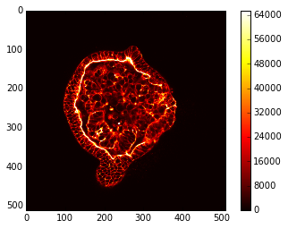

```python
imgplot = plt.imshow(img6d[0,0,70,0,:,:])
imgplot.set_cmap('hot')
plt.colorbar()
```